# Reproducible Research: Peer Assessment 1

Stefano Masneri

2016-03-02

## Before we start

We load all the library we need for the analysis

```r
library(ggplot2)
```

Then set some global options for knitr

```r
knitr::opts_chunk$set(fig.width=12, fig.height=8, fig.path='figures/', fig.keep='high' )
```

## Loading and preprocessing the data

To avoid repeating unnecessary operation, we perform a basic check: if the data does not exist in pur folder, we extract it from the zip file provided for the assignment.

```r
if ( !file.exists("activity.csv") ) {
  unzip('activity.zip')
}
activity <- read.csv("activity.csv")
```

We then proceed to make the data tidy, by converting dates into date objects.

```r
activity$date <- as.Date(activity$date, "%Y-%m-%d")
```

## What is mean total number of steps taken per day?

At first we just compute the total steps per day, ignoring any NAs, and then plot the histogram We then proceed to compute the mean and median value, and display it on the plot

```r
sumSteps <- tapply(activity$steps, activity$date, FUN = sum, na.rm = TRUE)
meanSteps <- mean(sumSteps, na.rm = TRUE)
meanSteps
```

```
## [1] 9354.23
```

```r
medianSteps <- median(sumSteps, na.rm = TRUE)
medianSteps
```

```
## [1] 10395
```

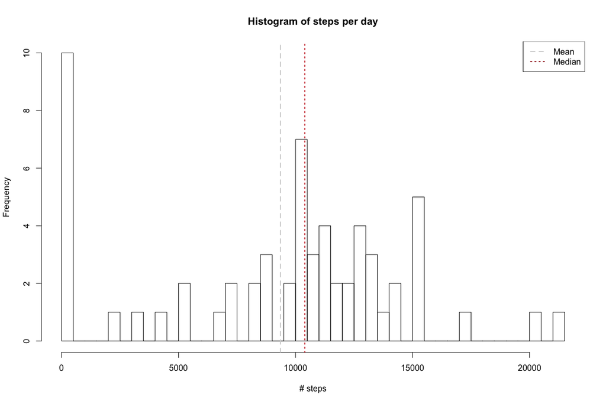

```r
hist( sumSteps, breaks = 50, main = "Histogram of steps per day", xlab = "# steps" )
abline( v = meanSteps, col='lightgray', lty = 2, lwd = 2)
abline( v = medianSteps, col='brown3', lty = 3, lwd = 2)
legend("topright", c("Mean", "Median"), lty = c(2, 3), lwd = c(2, 2), col = c('lightgray', 'brown'))
```

## What is the average daily activity pattern?

We have to compute the number of steps per time interval And then we extract the maximum value and its position

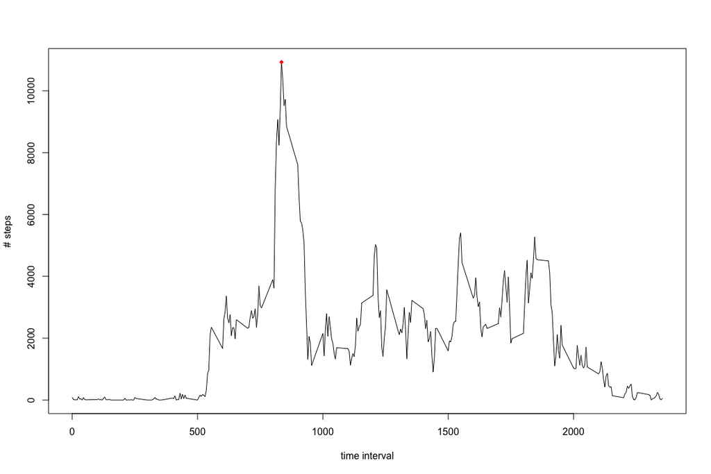

```r
sumStepsPerInterval <- aggregate(steps ~ interval, activity, FUN = sum, na.rm = TRUE)
plot(sumStepsPerInterval$interval, sumStepsPerInterval$steps, type = 'l', xlab = 'time interval', ylab = '# steps')
maxNumSteps <- max(sumStepsPerInterval$steps)
timeMaxSteps <- sumStepsPerInterval$interval[which.max(sumStepsPerInterval$steps)]
points(timeMaxSteps, maxNumSteps, col = 'red', pch = 18)
```

## Imputing missing values

```r
medianStepsPerInterval <- aggregate(steps ~ interval, activity, FUN = median, na.rm = TRUE)
NArows <- sum(is.na(activity))
NArows
```

```
## [1] 2304
```

```r
activityNoNAs <- activity
activityNoNAs$wasNA <- is.na(activity$steps)
medianArray <- rep(medianStepsPerInterval$steps,length(unique(activity$date)))
activityNoNAs[activityNoNAs$wasNA, ]$steps <- medianArray[activityNoNAs$wasNA]
```

## Are there differences in activity patterns between weekdays and weekends?

First, let’s define a new column, day, containing either weekday or weekend

```r
activityNoNAs$day <- "weekday"
activityNoNAs$day[weekdays(activityNoNAs$date) == "Sunday" | weekdays(activityNoNAs$date) == "Saturday" ] = "weekend"
activityNoNAs$day <- as.factor(activityNoNAs$day)
```

Then we can create a plot which highlights (if any) the different pattern according to whether it is weekend or not

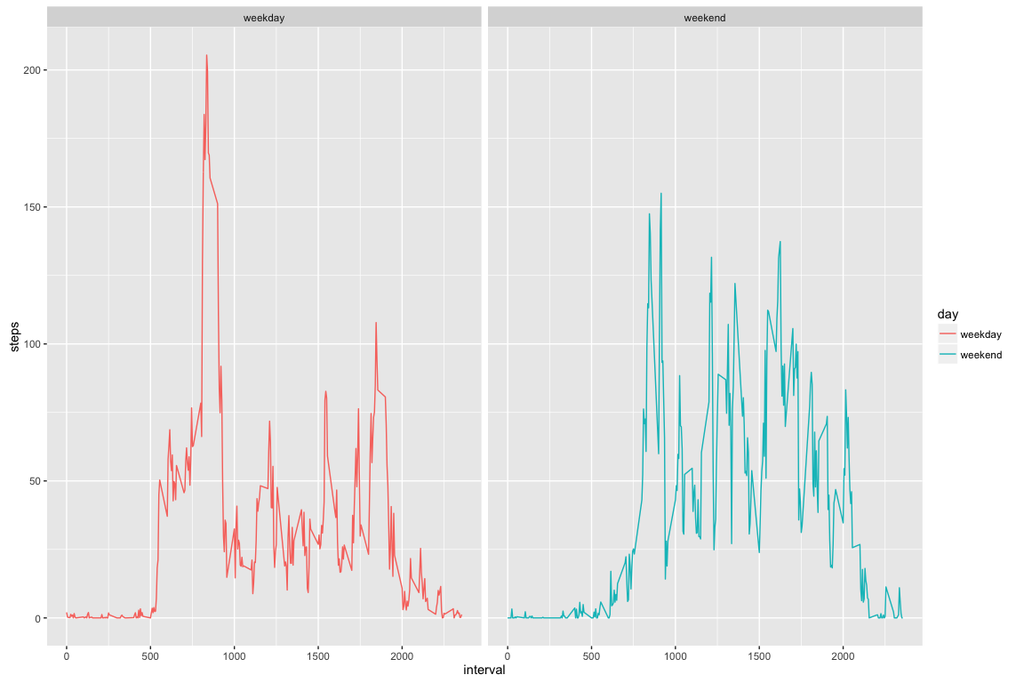

```r
stepsByDayAndInt <- aggregate(steps ~ interval+day, activityNoNAs, FUN = mean, na.rm = TRUE)
ggplot(stepsByDayAndInt, aes(x = interval, y = steps, color = day))  + facet_grid(. ~ day) + geom_line()
```